# Научная презентация

Дисциплина:Операционные системы

Абрамова У. М.

Российский университет дружбы народов, Москва, Россия

Математический институт имени Никольского, Москва, Россия

07.03.2025

# Информация

## Докладчик

- Абрамова Ульяна Михайловна
- Студент НММбд-01-24
- Российский университет дружбы народов
- 1132246782@pfur.ru
- https://github.com/Ulyana-abr

# Вводная часть

## Актуальность

- Данная модель отлично подходит для организации рабочего процесса на основе релизов.
- При использовании библиотеки расширений git-flow нужно инициализировать структуру в существующем репозитории

## Цели и задачи

- Получение навыков правильной работы с репозиториями git.
- Выполнить работу для тестового репозитория.
- Преобразовать рабочий репозиторий в репозиторий с git-flow и conventional commits.

## Материалы и методы

- git-flow
- Node.js
- Список лицензий для npm: https://spdx.org/licenses/

## Содержание исследования

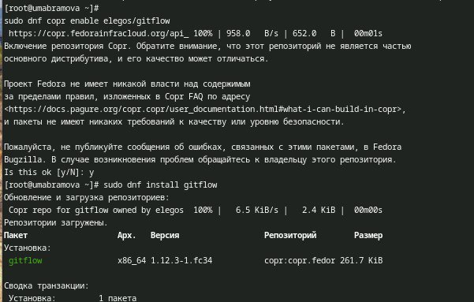

## Содержание исследования

Настраиваю node js (рис.2)

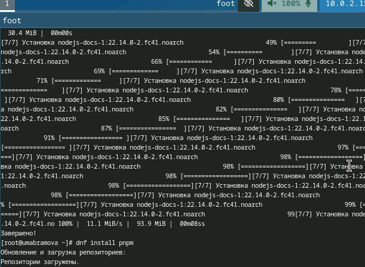

настройка node js

## Содержание исследования

Настраиваю конфигурацию общепринятых коммитов (рис.3)

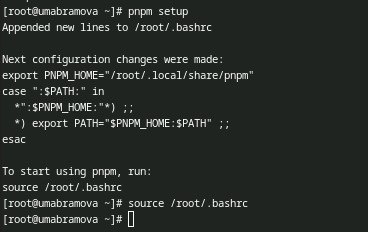

настройка общепринятых коммитов

## Содержание исследования

2. Практический сценарий использования git Создаю репозиторий git-extended (рис.4,5,6,7)

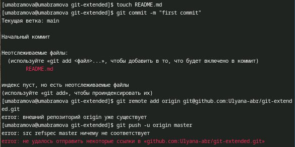

## Содержание исследования

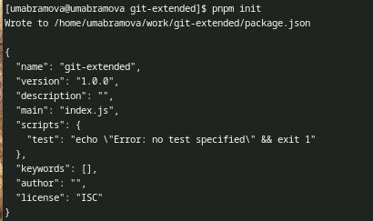

конфигурация общепринятых коммитов

## Содержание исследования

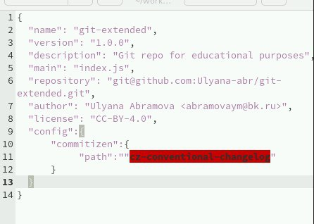

изменение файла package.json

## Содержание исследования

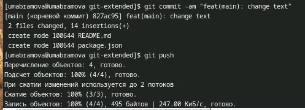

отправка на github

## Содержание исследования

Выполняю инициализацию git-flow, проверяю ветку и загружаю весь репозиторий в хранилище (рис.8)

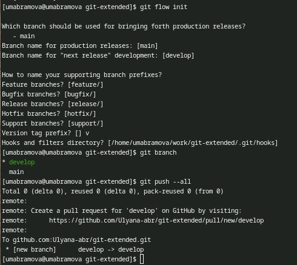

Конфигурация git-flow

## Содержание исследования

Устанавливаю внешнюю ветку, как вышестоящую и создаю релиз с версией 1.0.0 , затем добавляю журнал изменений в индекс и заливаю релизную ветку в основную (рис.9)

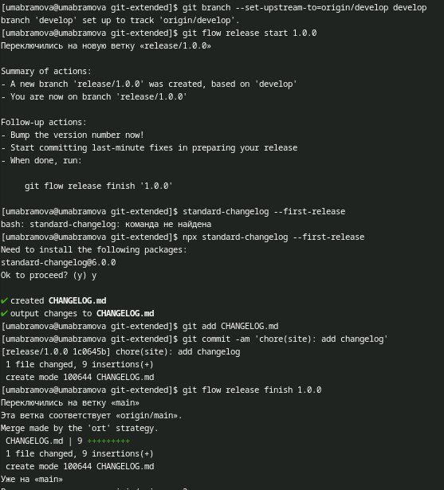

Конфигурация git-flow

## Содержание исследования

3. Работа с репозиторием git Разрабатываю ветку для новой функциональности (рис.10)

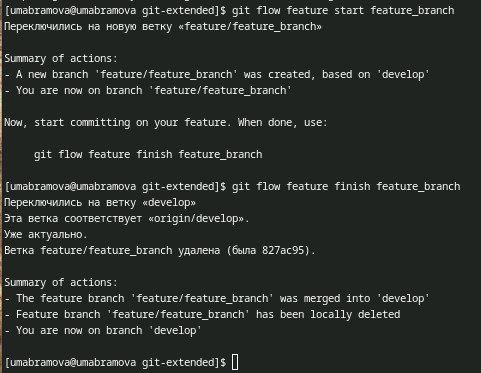

создание ветки для новой функциональности

## Содержание исследования

Создаю релиз с версией 1.2.3 (рис.11)

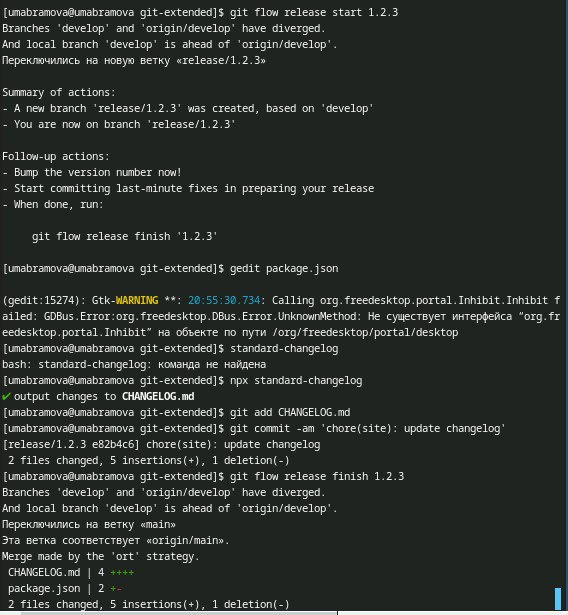

создание релиза

## Содержание исследования

Обновляю номер версии в package.json (рис.12)

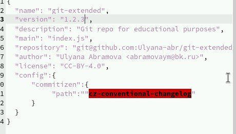

обновление номера версии

## Содержание исследования

Создаю журнал изменений, добавляю его в индекс и отправляю данные на github (рис.13)

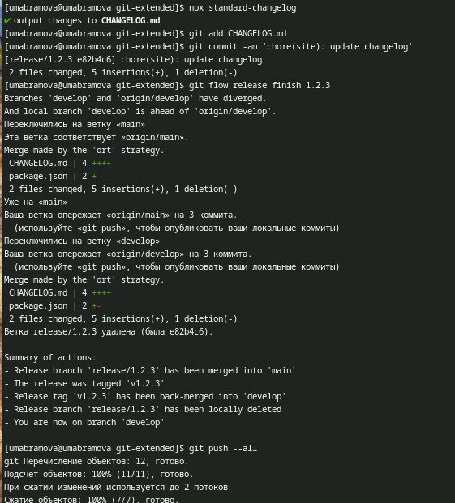

Создание релиза git-flow

## Содержание исследования

Создаю релиз с комментарием из журнала изменений (рис.14)

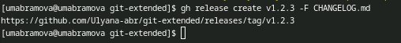

Создание релиза с комментарием из журнала изменений

## Итоговый слайд

- Чем больше вы практикуетесь и пробуете новое, тем больше и чаще вы будете получать знаний и опыта в разных сферах.